# A brief interrogation of circadian rhthym-related genes in Depmap melanoma data

Theo Killian

2025-02-15

# Introduction

This HTML report details an exploration of the nature of circadian genes in melanoma cell lines from the Broad Institute [Depmap](https://depmap.org/portal/data_page/?tab=allData) datasets using the [depmap R package](https://www.bioconductor.org/packages/release/data/experiment/html/depmap.html), cancer dependency data described by [Tsherniak, Aviad, et al. “Defining a cancer dependency map.” Cell 170.3 (2017): 564-576.](https://www.ncbi.nlm.nih.gov/pubmed/28753430). The DepMap data enables us to look at CRISPR essentiality, copy number, mutation calls, and transcript expression for a large panel of cancer cell lines, including melanoma.

## Gene lists

We will interrogate Depmap data using a curated list of genes that regulate the human circadian rhythm, which were taken from the publication [The Circadian Clock Component RORA Increases Immunosurveillance in Melanoma by Inhibiting PD-L1 Expression, Liu, et al. 2024](https://pmc.ncbi.nlm.nih.gov/articles/PMC11247325/).

```r
circadian_gene_list <- c(
  "RORA", "PER3", "PER1", "CRY2", "RORB", "PER2", "NR1D2", "RORC", "CRY1",
  "ARNTL", "NPAS2", "CLOCK", "NR1D1", "ARNTL2")

# driver_gene_list <- c(
#   "BRAF", "NRAS", "NF1", "CDKN2A", "PTEN", "TP53", "TERT", "KIT", "GNAQ",
#   "GNA11", "MITF", "MC1R", "CDK4")
```

### Biomart

Here, we connect to Ensembl via biomaRt (disabled by `eval=FALSE` so it doesn’t automatically run each time). This code retrieves gene metadata (e.g., gene names, coordinates) and saves it as an `.rds` file.

```r
## Connect to the Ensembl database
ensembl <- useMart("ensembl", dataset = "hsapiens_gene_ensembl")

## get information for all human genes (to be used later)
getBM(
  attributes = c(
  "external_gene_name", "description", "entrezgene_id", "ensembl_gene_id",
  "chromosome_name", "start_position", "end_position"),
      mart = ensembl) %>%
  dplyr::rename(gene_name = external_gene_name,
                entrez_id = entrezgene_id,
                ensembl_id = ensembl_gene_id,
                chromosome = chromosome_name,
                start = start_position,
                end = end_position) %>%
  dplyr::filter(stringr::str_length(gene_name) > 1,
                stringr::str_length(chromosome) < 3) %>%
  dplyr::mutate(description = gsub("\\[Source:.*", "", description)) %>%
  as.data.frame() -> human_genes

saveRDS(human_genes, file = "./data/human_genes.rds")
```

```r
human_genes <- readRDS(file = "./data/human_genes.rds")
```

```r
human_genes %>%
  dplyr::filter(gene_name %in% circadian_gene_list) %>%
  dplyr::arrange(gene_name) %>%
  as.data.frame() -> circadian_genes

# human_genes %>%
#   dplyr::filter(gene_name %in% driver_gene_list) %>%
#   dplyr::arrange(gene_name) %>%
#   as.data.frame() -> driver_genes

DT::datatable(circadian_genes)
```

|  | gene_name | description | entrez_id | ensembl_id | chromosome | start | end |
| --- | --- | --- | --- | --- | --- | --- | --- |
| 1 | CLOCK | clock circadian regulator | 9575 | ENSG00000134852 | 4 | 55427903 | 55546909 |
| 2 | CRY1 | cryptochrome circadian regulator 1 | 1407 | ENSG00000008405 | 12 | 106991364 | 107093549 |
| 3 | CRY2 | cryptochrome circadian regulator 2 | 1408 | ENSG00000121671 | 11 | 45847118 | 45883248 |
| 4 | NPAS2 | neuronal PAS domain protein 2 | 4862 | ENSG00000170485 | 2 | 100820139 | 100996829 |
| 5 | NR1D1 | nuclear receptor subfamily 1 group D member 1 | 9572 | ENSG00000126368 | 17 | 40092793 | 40100589 |
| 6 | NR1D2 | nuclear receptor subfamily 1 group D member 2 | 9975 | ENSG00000174738 | 3 | 23945286 | 23980637 |
| 7 | PER1 | period circadian regulator 1 | 5187 | ENSG00000179094 | 17 | 8140467 | 8156506 |
| 8 | PER2 | period circadian regulator 2 | 8864 | ENSG00000132326 | 2 | 238244044 | 238290102 |
| 9 | PER3 | period circadian regulator 3 | 8863 | ENSG00000049246 | 1 | 7784291 | 7845177 |
| 10 | RORA | RAR related orphan receptor A | 6095 | ENSG00000069667 | 15 | 60488284 | 61229302 |

[output cut: 2 more lines]

## Depmap

We create an `ExperimentHub` object to pull relevant DepMap datasets:

```
crispr: CRISPR-Cas9 essentiality (dependency) scores
copyNumber: copy number alterations per gene/cell line
TPM: transcript expression levels (RNA-seq)
mutationCalls: mutation data
metadata: cell-line metadata (including disease subtype).
```

```r
## create ExperimentHub query object
eh <- ExperimentHub()
query(eh, "depmap")
```

```
#> ExperimentHub with 82 records
#> # snapshotDate(): 2024-10-24
#> # $dataprovider: Broad Institute
#> # $species: Homo sapiens
#> # $rdataclass: tibble
#> # additional mcols(): taxonomyid, genome, description,
#> #   coordinate_1_based, maintainer, rdatadateadded, preparerclass, tags,
#> #   rdatapath, sourceurl, sourcetype
#> # retrieve records with, e.g., 'object[["EH2260"]]'
#>
#>            title
#>   EH2260 | rnai_19Q1
#>   EH2261 | crispr_19Q1
#>   EH2262 | copyNumber_19Q1
#>   EH2263 | RPPA_19Q1
#>   EH2264 | TPM_19Q1
#>   ...      ...
#>   EH7555 | copyNumber_22Q2
#>   EH7556 | TPM_22Q2
#>   EH7557 | mutationCalls_22Q2
#>   EH7558 | metadata_22Q2
#>   EH7559 | achilles_22Q2
```

```r
metadata <- eh[["EH7558"]]
crispr <- eh[["EH7554"]]
copyNumber <- eh[["EH7555"]]
TPM <- eh[["EH7556"]]
mutationCalls <- eh[["EH7557"]]
```

## Metadata

We subset DepMap metadata for melanoma lines using keywords (“melanoma”) across relevant columns. We display the resulting set of melanoma cell lines in a datatable for easy scanning.

```r
metadata %>%
  dplyr::filter(grepl("melanoma", lineage_subtype) |
                grepl("elanoma", Cellosaurus_NCIt_disease) |
                grepl("elanoma", subtype_disease) |
                grepl("elanoma", cell_line)) %>%
  dplyr::select(-contains("issues")) %>%
  as.data.frame() -> melanoma_metadata

DT::datatable(melanoma_metadata)
```

|  | depmap_id | cell_line_name | stripped_cell_line_name | cell_line | aliases | cosmic_id | sex | source | RRID | WTSI_master_cell_ID | sample_collection_site | primary_or_metastasis | primary_disease | subtype_disease | age | sanger_id | additional_info | lineage | lineage_subtype | lineage_sub_subtype | lineage_molecular_subtype | default_growth_pattern | model_manipulation | model_manipulation_details | patient_id | parent_depmap_id | Cellosaurus_NCIt_disease | Cellosaurus_NCIt_id |
| --- | --- | --- | --- | --- | --- | --- | --- | --- | --- | --- | --- | --- | --- | --- | --- | --- | --- | --- | --- | --- | --- | --- | --- | --- | --- | --- | --- | --- |
| 1 | ACH-000043 | Hs 895.T | HS895T | HS895T_FIBROBLAST |  |  | Female | ATCC | CVCL_0993 |  | fibroblast | Metastasis | Non-Cancerous | Skin | 48 |  |  | fibroblast | fibroblast_skin |  |  | 2D: adherent |  |  | PT-rTUVZQ |  | Melanoma | C3224 |
| 2 | ACH-000180 | Hs 839.T | HS839T | HS839T_FIBROBLAST |  |  | Female | ATCC | CVCL_0941 |  | fibroblast |  | Non-Cancerous | Skin | 42 |  |  | fibroblast | fibroblast_skin |  |  | 2D: adherent |  |  | PT-aCAmcw |  | Melanoma | C3224 |
| 3 | ACH-000194 | Hs 934.T | HS934T | HS934T_FIBROBLAST |  |  | Female | ATCC | CVCL_1031 |  | fibroblast | Primary | Non-Cancerous | Skin | 58 |  |  | fibroblast | fibroblast_skin |  |  | 2D: adherent |  |  | PT-RKnqyJ |  | Melanoma | C3224 |
| 4 | ACH-000275 |  | HS834T | HS834T_FIBROBLAST |  |  | Female |  | CVCL_0938 |  | lymph_node | Metastasis | Non-Cancerous | Skin | 27 |  |  | fibroblast | fibroblast_skin |  |  | 2D: adherent |  |  | PT-CaS06R |  | Melanoma | C3224 |
| 5 | ACH-000801 | Hs 936.T | HS936T | HS936T_SKIN |  |  | Male | ATCC | CVCL_1033 |  | skin |  | Skin Cancer | Melanoma |  |  |  | skin | melanoma |  |  | 2D: adherent |  |  | PT-1I8hCi |  | Melanoma | C3224 |
| 6 | ACH-000899 | WM-88 | WM88 | WM88_SKIN |  |  | Male | Academic lab | CVCL_6805 |  | skin | Metastasis | Skin Cancer | Melanoma |  |  |  | skin | melanoma |  |  | 2D: adherent |  |  | PT-j60QIc |  | Melanoma | C3224 |
| 7 | ACH-001045 |  | COLO849 | COLO849_SKIN |  |  | Male | DSMZ | CVCL_2002 |  | lymph_node | Metastasis | Skin Cancer | Melanoma | 43 |  |  | skin | melanoma |  |  |  |  |  | PT-w6ABKA |  | Cutaneous melanoma | C3510 |
| 8 | ACH-001441 | 92-1 | 921 | 921_UVEA |  |  | Female | Sigma-Aldrich | CVCL_8607 |  | uvea | Metastasis | Eye Cancer | Uveal Melanoma | 76 |  |  | eye | uveal_melanoma |  |  | 2D: adherent |  |  | PT-jIJ6sz |  | Uveal melanoma | C7712 |
| 9 | ACH-001569 | MM415 | MM415 | MM415_SKIN |  |  | Male | Sigma-Aldrich | CVCL_2608 |  | lymph_node | Metastasis | Skin Cancer | Melanoma |  |  |  | skin | melanoma |  |  | 2D: adherent |  |  | PT-XeUtGz |  | Melanoma | C3224 |
| 10 | ACH-001970 | MM253 | MM253 | MM253_SKIN | MM 253, MM-253 |  | Male | CellBank Australia | CVCL_2604 |  | lymph_node | Metastasis | Skin Cancer | Melanoma | 46 |  |  | skin | melanoma |  |  | 2D: adherent |  |  | PT-75oSJn |  | Amelanotic melanoma | C3802 |

[output cut: 114 more lines]

## CRISPR Dependency

We visualize how dependent these cell lines are on each circadian gene using [plotly](https://plotly.com/r/. The dashed lines represent:

```
Red line: the mean dependency across all circadian genes in just melanoma lines.
Green line: the mean dependency across all lines and all genes in DepMap (global average).
```

```r
crispr %>%
  dplyr::filter(cell_line %in% melanoma_metadata$cell_line,
                gene_name %in% circadian_genes$gene_name,
                !is.na(cell_line)) %>%
  as.data.frame() -> crispr_df

crispr %>%
  dplyr::filter(!is.na(dependency)) %>%
  as.data.frame() -> crispr_global_dependency

crispr_df %>%
  dplyr::filter(!is.na(dependency)) %>%
  dplyr::group_by(gene_name) %>%
  dplyr::summarize(mean_dependency = mean(dependency, na.remove = TRUE)) %>%
  as.data.frame() -> crispr_gene_mean_dep

crispr_df %>%
  dplyr::left_join(crispr_gene_mean_dep, by = "gene_name") %>%
  dplyr::arrange(desc(mean_dependency)) %>%
  dplyr::mutate(gene_name = factor(gene_name, levels = unique(gene_name))) %>%
  dplyr::select(-c(gene, cell_line)) %>%
  dplyr::left_join(metadata, by = "depmap_id") %>%
  as.data.frame() -> crispr_gene_mean_dep_merged

crispr_gene_mean_dep_merged %>%
  ggplot(aes(x = gene_name, y = dependency, color = subtype_disease)) +
  geom_point(size = 0.75) +
  theme_classic() +
  theme(axis.text.x = element_text(angle = 45, hjust = 1)) +
  geom_hline(yintercept = mean(crispr_gene_mean_dep$mean_dependency, na.remove = TRUE),
             color = "darkred", linetype = "dashed") +
  geom_hline(yintercept = mean(crispr_global_dependency$dependency, na.remove = TRUE),
             color = "darkgreen", linetype = "dashed") +
  xlab("circadian rhythm-related genes") +
  ggtitle("Circadian rhythm-related genes ranked by descending mean dependency score") -> p1
ggplotly(p1)
```

[interactive chart not shown]

We reshape (`pivot_wider`) the data so that `rows = genes`, `columns = melanoma` cell lines, and `values = CRISPR` dependency scores. Then we call `pheatmap` to visualize how essential each gene is across multiple lines in a grid layout.

**Interpretation: we don’t observe a strong pattern in dependency scores in circadian genes in melanoma cell lines**

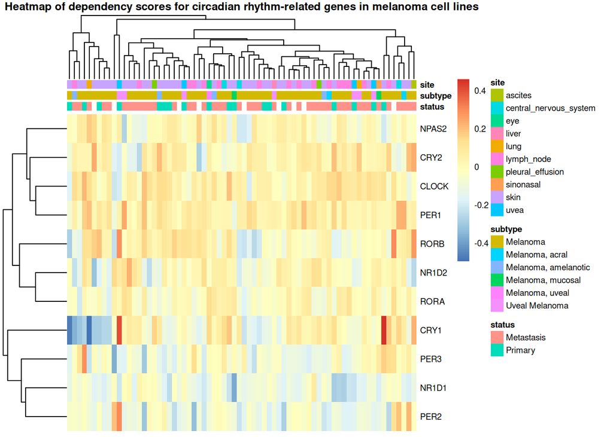

```r
crispr_df %>%
  dplyr::select(gene_name, cell_line, dependency) %>%
  tidyr::pivot_wider(names_from = cell_line,
                     values_from = dependency) %>%
  tibble::column_to_rownames(var = "gene_name") %>%
  t() %>% as.data.frame() %>%
  tibble::rownames_to_column(var = "cell_line") %>%
  dplyr::left_join(melanoma_metadata, by = "cell_line") %>%
  as.data.frame() -> crispr_ann_df

data.frame(status = crispr_ann_df$primary_or_metastasis,
           subtype = crispr_ann_df$subtype_disease,
           site = crispr_ann_df$sample_collection_site,
           row.names = crispr_ann_df$cell_line) -> sample_col

crispr_ann_df %>%
  dplyr::select(cell_line:RORB) %>%
  tibble::column_to_rownames(var = "cell_line") %>%
  t() %>%
  pheatmap::pheatmap(
    annotation_col = sample_col,
    show_colnames = FALSE,
    border_color = NA,
    fontsize = 7,
    main = paste0("Heatmap of dependency scores for circadian rhythm-related ",
                  "genes in melanoma cell lines"))
```

### Copy Number

We check log2 copy-number values per gene. A dashed line at `y=1` (or `y=0`, depending on your scale) might indicate a diploid reference. Higher or lower values suggest possible amplification or deletion for these circadian genes in melanoma cells. The genes are arranged by descending average copy number. For more information how Depmap CNV is calculated, please refer to the [DepMap documentation](https://depmap.sanger.ac.uk/documentation/datasets/copy-number/).

**Interpretation: RORC average copy number is highest in melanoma, but also displays the greatest variation. The other circadian-related genes display variation, but their mean CNV is close to 1**

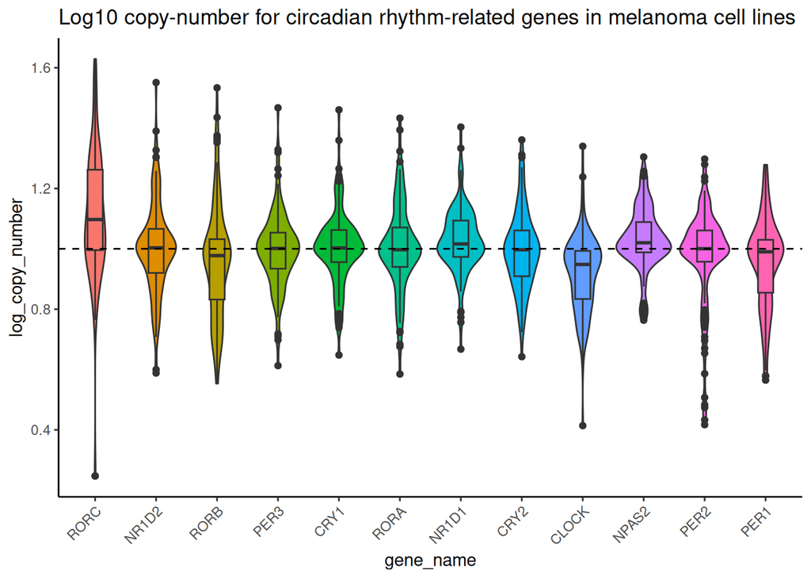

```r
copyNumber %>%
  dplyr::filter(cell_line %in% melanoma_metadata$cell_line,
                gene_name %in% circadian_genes$gene_name,
                !is.na(cell_line)) %>%
  as.data.frame() -> copy_number_df

copy_number_df %>%
  dplyr::arrange(desc(log_copy_number)) %>%
  dplyr::mutate(gene_name = factor(gene_name, levels = unique(gene_name))) %>%
  ggplot(aes(x = gene_name, y = log_copy_number, fill = gene_name)) +
    geom_violin() +
    geom_boxplot(width = 0.25) +
    theme_classic() +
    theme(axis.text.x = element_text(angle = 45, hjust = 1),
          legend.position = "none") +
    geom_hline(yintercept = 1, color = "black", linetype = "dashed") +
    ggtitle(paste0("Log10 copy-number for circadian rhythm-related genes in",
                   " melanoma cell lines"))
```

### Gene Expression

We pivot from long to wide, building a matrix of TPM expression with genes as rows and cell lines as columns. Then we optionally annotate columns with metadata (`metastatic status`, `disease subtype`) and generate a `pheatmap` to see expression clustering.

**Interpretation: Expression of PER2, RORA, RORB and RORC appears to be very low in all melanome cell lines. NPAS expression is the most elevated, while the remaining genes display expression somewhere in between.**

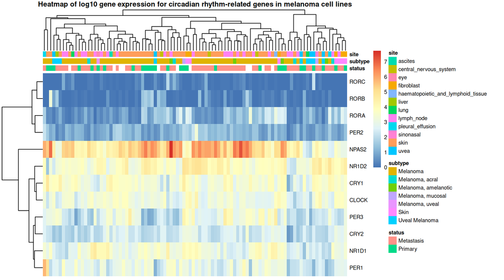

```r
TPM %>%
  dplyr::filter(cell_line %in% melanoma_metadata$cell_line,
                gene_name %in% circadian_genes$gene_name,
                !is.na(cell_line)) %>%
  as.data.frame() -> tpm_df

tpm_df %>%
  dplyr::select(gene_name, cell_line, rna_expression) %>%
  tidyr::pivot_wider(names_from = cell_line,
                     values_from = rna_expression) %>%
  tibble::column_to_rownames(var = "gene_name") %>%
  t() %>% as.data.frame() %>%
  tibble::rownames_to_column(var = "cell_line") %>%
  dplyr::left_join(melanoma_metadata, by = "cell_line") %>%
  as.data.frame() -> tpm_ann_df

data.frame(status = tpm_ann_df$primary_or_metastasis,
           subtype = tpm_ann_df$subtype_disease,
           site = tpm_ann_df$sample_collection_site,
           row.names = tpm_ann_df$cell_line) -> sample_col

tpm_ann_df %>%
  dplyr::select(cell_line:RORB) %>%
  tibble::column_to_rownames(var = "cell_line") %>%
  t() %>%
  pheatmap::pheatmap(
    annotation_col = sample_col,
    fontsize = 7,
    border_color = NA,
    show_colnames = FALSE,
    main = paste0("Heatmap of log10 gene expression for circadian rhythm-related ",
                  "genes in melanoma cell lines"))
```

We join CRISPR dependency data with expression (`TPM`) for the same gene/cell line pairs, then plot expression vs. dependency. The `stat_cor(method = "spearman")` call adds a correlation value to see if higher expression correlates with lower (or higher) essentiality.

**Interpretation: We don’t observe a signfificant direct correlation between any circadian rhythm gene expression and CRISPR dependency scores.**

*Note: Normally, we would expect a relationship where increased gene expression displays increased dependency, if such a gene dependency exists.*

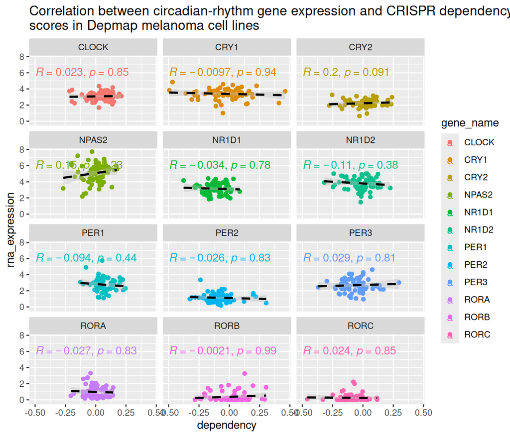

```r
tpm_df %>%
  dplyr::select(-c(gene, cell_line, entrez_id)) %>%
  dplyr::left_join(crispr_df, by = c("depmap_id", "gene_name")) %>%
  dplyr::filter(!is.na(cell_line)) %>%
  ggplot(aes(x = dependency, y = rna_expression, colour = gene_name)) +
    geom_point() +
    stat_smooth(method = "lm", se = TRUE, formula = y ~ poly(x, 1, raw = TRUE),
                color = "black", linetype = "dashed", fill = "gray") +
    ggpubr::stat_cor(method = "spearman", label.x = -0.5, label.y = 6) +
    ggtitle(paste0("Correlation between circadian-rhythm gene expression and ",
                   "CRISPR dependency\nscores in Depmap melanoma cell lines")) +
    facet_wrap(~gene_name, ncol = 3)
```

### Mutation Calls

We look at mutationCalls table, combine with metadata, and keep only those entries with a circadian gene in melanoma cell lines.

```r
mutationCalls %>%
  dplyr::left_join(melanoma_metadata, by = "depmap_id") %>%
  dplyr::filter(cell_line %in% melanoma_metadata$cell_line,
                gene_name %in% circadian_genes$gene_name,
                !is.na(cell_line)) %>%
  as.data.frame() -> mutation_calls_df
```

We create a balloon plot to see how mutation classification (e.g., “Missense”, “Nonsense”, “Splice site”) differs between primary vs. metastatic cell lines.

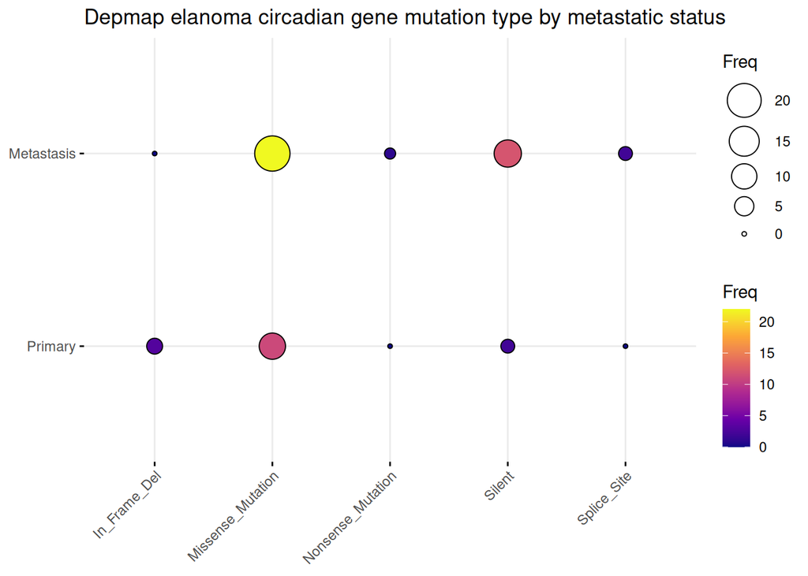

```r
table(mutation_calls_df$var_class, mutation_calls_df$primary_or_metastasis) %>%
  as.data.frame() %>%
  ggballoonplot(fill = "value") +
    scale_fill_gradientn(colors = my_cols) +
    ggtitle("Depmap elanoma circadian gene mutation type by metastatic status")
```

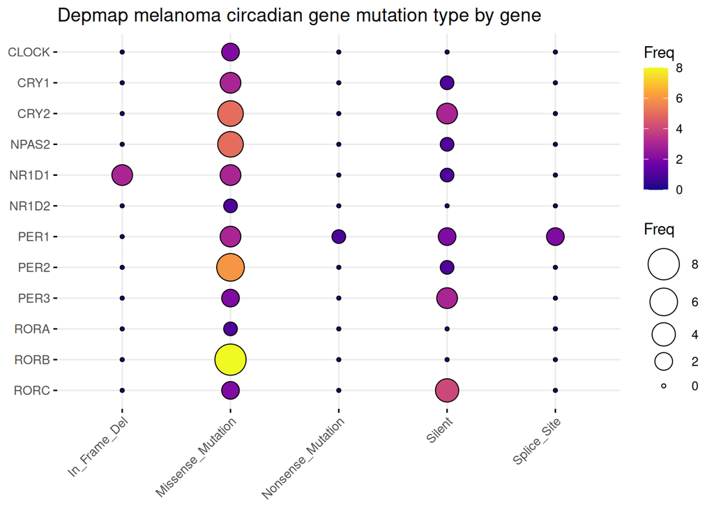

```r
table(mutation_calls_df$var_class, mutation_calls_df$gene_name) %>%
  as.data.frame() %>%
  ggballoonplot(fill = "value") +
    scale_fill_gradientn(colors = my_cols) +
    ggtitle("Depmap melanoma circadian gene mutation type by gene")
```

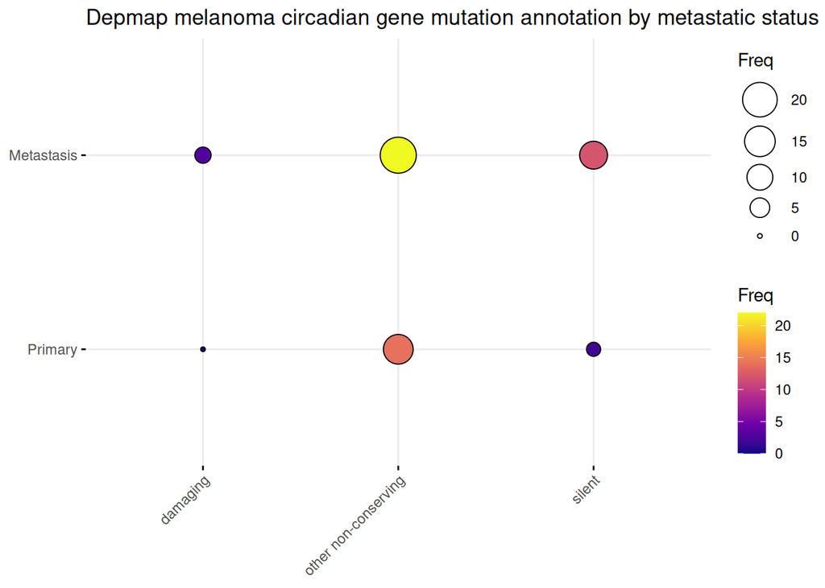

```r
table(mutation_calls_df$var_annotation, mutation_calls_df$primary_or_metastasis) %>%
  as.data.frame() %>%
  ggballoonplot(fill = "value") +
    scale_fill_gradientn(colors = my_cols) +
    ggtitle("Depmap melanoma circadian gene mutation annotation by metastatic status")
```

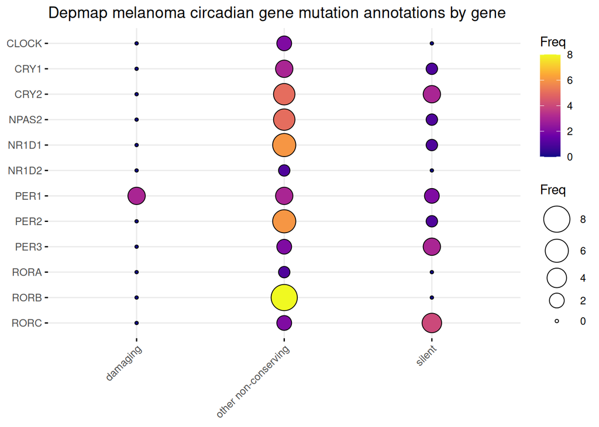

```r
table(mutation_calls_df$var_annotation, mutation_calls_df$gene_name) %>%
  as.data.frame() %>%
  ggballoonplot(fill = "value") +
    scale_fill_gradientn(colors = my_cols) +
    ggtitle("Depmap melanoma circadian gene mutation annotations by gene")
```

*UV Exposure: In primary cutaneous melanomas, C to T (and symmetrically G to A) transitions at dipyrimidine sites are the prototypical “UV signature.” Given the strong etiological of melanoma link with UV radiation, it is no surprise these transitions dominate.*

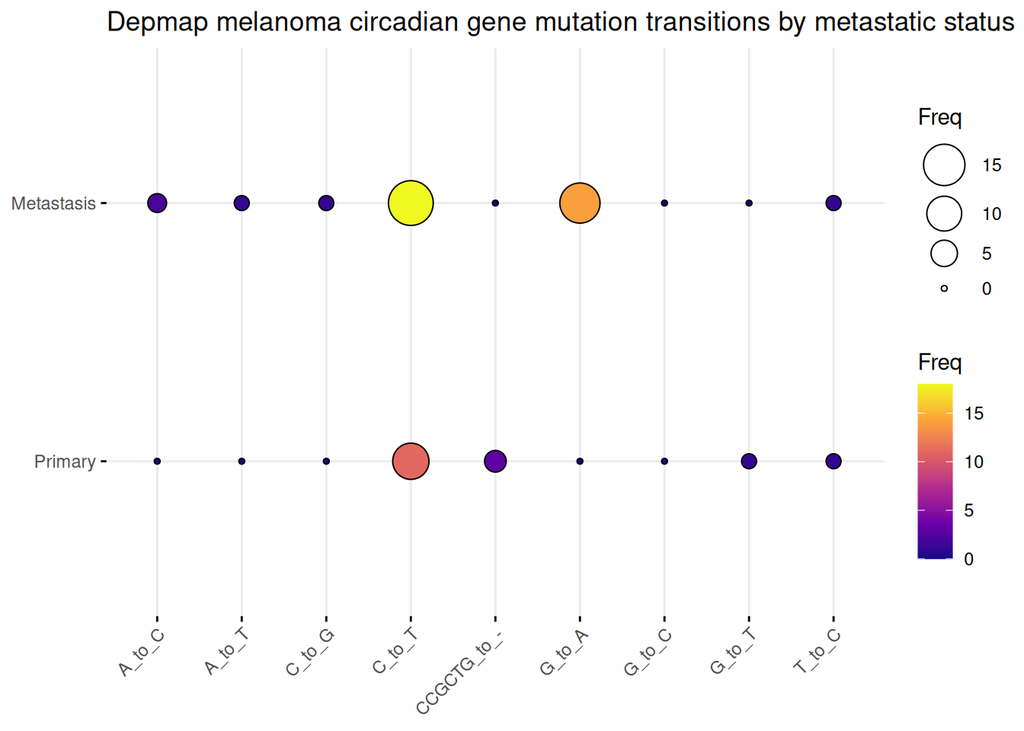

```r
mutation_calls_df %>%
  dplyr::mutate(mutation_type = paste0(ref_allele, "_to_", alt_allele)) %>%
  as.data.frame() -> mutation_calls_df2

table(mutation_calls_df2$mutation_type, mutation_calls_df2$primary_or_metastasis) %>%
  as.data.frame() %>%
  ggballoonplot(fill = "value") +
    scale_fill_gradientn(colors = my_cols) +
    ggtitle("Depmap melanoma circadian gene mutation transitions by metastatic status")
```

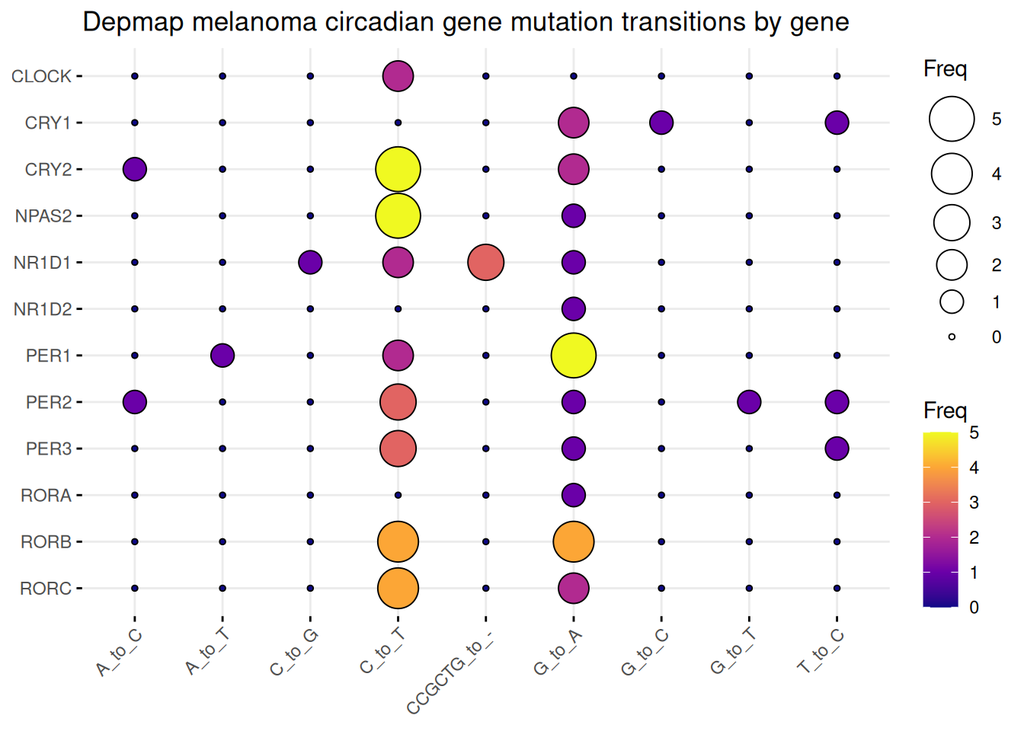

```r
mutation_calls_df %>%
  dplyr::mutate(mutation_type = paste0(ref_allele, "_to_", alt_allele)) %>%
  as.data.frame() -> mutation_calls_df2

table(mutation_calls_df2$mutation_type, mutation_calls_df2$gene_name) %>%
  as.data.frame() %>%
  ggballoonplot(fill = "value") +
    scale_fill_gradientn(colors = my_cols) +
    ggtitle("Depmap melanoma circadian gene mutation transitions by gene")
```

## Summary

This exploration underscores the utility of DepMap data and R-based visualization workflows to generate hypotheses about circadian gene roles in melanoma cell-line survival, copy number changes, and potentially UV-signature–associated mutations.